# Power curves for 12 scenarios

권대영, 민태원

2023-02-10

## (1) Specification: Choose 12 scenarios (HR, Delta_y)

- N: Number of simulations = 5,000
- n: Number of generated samples per group = 500
- Group2 is treated group
- one-sided, alpha = 0.05, beta = 0 ~ 0.05 (by 0.0005)
- $\Delta_y = \frac{\mu_{y2} - \mu_{y1}}{\sqrt{2}\sigma_{y1}} \in \{0.0, 0.02, 0.04\}$ is the primary outcome of interest ($\mu_{y1} = 0$, $\sigma_{y1} = 1$)
- $\begin{pmatrix} Y_1 \\ Y_2 \end{pmatrix} \sim N \begin{pmatrix} \begin{pmatrix} 0\\\sqrt{2} \Delta_y \end{pmatrix}, \begin{pmatrix} \sigma^2_{y1} & \rho_y\sigma_{y1}\sigma_{y2} \\ \rho_y\sigma_{y1}\sigma_{y2} & \sigma^2_{y2} \end{pmatrix} \end{pmatrix}$, $\rho_y=0.8$, $\sigma_{y1}=\sigma_{y2}=1$
- $p_i = E(\delta_{ij}) = \mathrm{Pr}(\delta_{ij}=1) = \mathrm{Pr}(t_{ij} \leq T)$ is the probability of truncated by death at observed time T for group i
- $q_i = 1-p_i = \mathrm{Pr}(t_{ij} > T), \quad i = 1, 2$ is the probability of survival at observed time T
- $q_2 \in \{0.6, 0.8, 0.9\}=\{low, mid, high\}, \quad T = 3$
- $\text{HR(Hazard Ratio)} \in \{1, 1.05, 1.1, 1.2\}$

## (2) Power Simulation

### (a) Survival time follows exponential distribution

#### Power for sequential test

```r
#Define parameters
Delta = c(0.0, 0.02, 0.04)
q2 = c(0.6, 0.8, 0.9)
HR = c(1.0, 1.05, 1.1, 1.2)
time = 3
N = 5000
n = 500
rho_t = 0.8
rho_Y = 0.8
alpha = 0.05
beta = seq(0, 0.05, by=5e-4)

simulate.exp.both <- function(n, q2, HR, Delta, time, rho_Y, rho_t){
  lambda2 = -1 / time * log(q2)
  lambda1 = lambda2 * HR
  #q1 = exp(-lambda1 * t)

  corr_t = matrix(c(1, rho_t, rho_t, 1), nrow = 2)
  t = rmvexp(n, rate=c(lambda1, lambda2), corr=corr_t)
  t1 = t[,1]
  t2 = t[,2]

  corr_Y = matrix(c(1, rho_Y, rho_Y, 1), nrow = 2)
  Y = rmvnorm(n, mean = c(0, 2^0.5 * Delta), cov = corr_Y)
  Y1 = Y[,1]
  Y2 = Y[,2]

  eta = min(Y) - 1 - time - 2 *(max(Y)-min(Y)) # in order to be worst
  distmin = min(abs(Y1-Y2))/time/10 # less than minimum difference between Y1 and Y2 divided by time

  Y1_tilde = Y1 * (t1 >= time) + (eta + t1*distmin) * (t1 < time)
  Y2_tilde = Y2 * (t2 >= time) + (eta + t2*distmin) * (t2 < time)

  Y1_survivorOnly = Y1[t1 >= time & t2 >= time]
  Y2_survivorOnly = Y2[t1 >= time & t2 >= time]

  if (length(Y1_survivorOnly) == 0) {
    return (c(-1,-1,-1))
  }

  pval.2 = wilcox.test(Y1_tilde, Y2_tilde, alternative="less", paired=T)$p.value

  OnlyControlDead = sum(t1 < time & t2 >= time)
  OnlyTreatedDead = sum(t2 < time & t1 >= time)
  if (OnlyControlDead == 0 & OnlyTreatedDead == 0) return (c(-1,-1)); # no discordant pair
  pval = binom.test(c(OnlyControlDead, OnlyTreatedDead), alternative = "greater")$p.value;
  if (pval <= alpha) {return (c(pval, pval.2));}
  else {
    if (OnlyTreatedDead == 0) {pval.alt = 0;}
    else {pval.alt = binom.test(c(OnlyControlDead+1, OnlyTreatedDead-1), alternative = "greater")$p.value;}

    if (pval.alt > alpha) { return (c(pval, pval.2)); }
    else {
      return (c(1 - rbinom(1, 1, (alpha - pval.alt)/(pval - pval.alt)), pval.2)); # auxiliary random
    }
  }
}
```

```r
power.exp.seq = array(data = NA, dim=c(length(q2), length(Delta), length(HR), length(beta)), dimnames = list(c("q2=60%", "q2=80%", "q2=90%"), c(0.0, 0.02, 0.04), c(1.0, 1.05, 1.1, 1.2), seq(0, 0.05, by=5e-4)))

set.seed(123)
for (i in 1:length(q2)) {
  cat("q2: ", q2[i], "\n")
  for (j in 1:length(Delta)) {
    cat("Delta: ", Delta[j], "\n")
    for (k in 1:length(HR)) {
      cat("HR: ", HR[k], "\n")
      count = array(0, length(beta))
      total = 0
      for (l in c(1:N)) {
        pvals = simulate.exp.both(n, q2[i], HR[k], Delta[j], time, rho_Y, rho_t)
        if (pvals[1] == -1 || pvals[2] == -1) {
          cat("every pairs died at ", l, "-th simluation")
          next;
        }
        total = total + 1
        for (b in 1:length(beta)) {
          if (pvals[1] <= beta[b]) {count[b] = count[b] + 1}
          else if (pvals[2] <= (alpha - beta[b])) {count[b] = count[b] + 1}
        }
      }
      power.exp.seq[i,j,k,] = count/total
    }
  }
}
```

[output not shown]

#### plot

```r
exp.seq.q2low = power.exp.seq[1,,,]
exp.seq.q2mid = power.exp.seq[2,,,]
exp.seq.q2high = power.exp.seq[3,,,]
```

##### (1) q2 = low (60%)

```r
power_delta0_hr1.0 = exp.seq.q2low[1,1,] # Delta = 0, HR = 1
power_delta0_hr1.05 = exp.seq.q2low[1,2,] # Delta = 0, HR = 1.05
power_delta0_hr1.1 = exp.seq.q2low[1,3,] # Delta = 0, HR = 1.1
power_delta0_hr1.2 = exp.seq.q2low[1,4,] # Delta = 0, HR = 1.2

power_delta0.02_hr1.0 = exp.seq.q2low[2,1,] # Delta = 0.02, HR = 1
power_delta0.02_hr1.05 = exp.seq.q2low[2,2,] # Delta = 0.02, HR = 1.05
power_delta0.02_hr1.1 = exp.seq.q2low[2,3,] # Delta = 0.02, HR = 1.1
power_delta0.02_hr1.2 = exp.seq.q2low[2,4,] # Delta = 0.02, HR = 1.2

power_delta0.04_hr1.0 = exp.seq.q2low[3,1,] # Delta = 0.04, HR = 1
power_delta0.04_hr1.05 = exp.seq.q2low[3,2,] # Delta = 0.04, HR = 1.05
power_delta0.04_hr1.1 = exp.seq.q2low[3,3,] # Delta = 0.04, HR = 1.1
power_delta0.04_hr1.2 = exp.seq.q2low[3,4,] # Delta = 0.04, HR = 1.2

df = data.frame(beta = rep(beta, 12),
group = rep(c("delta0_hr1.0","delta0_hr1.05","delta0_hr1.1","delta0_hr1.2",
              "delta0.02_hr1.0","delta0.02_hr1.05","delta0.02_hr1.1","delta0.02_hr1.2",
              "delta0.04_hr1.0","delta0.04_hr1.05","delta0.04_hr1.1","delta0.04_hr1.2"), each=length(beta)), power =
c(power_delta0_hr1.0, power_delta0_hr1.05, power_delta0_hr1.1, power_delta0_hr1.2,
  power_delta0.02_hr1.0,power_delta0.02_hr1.05,power_delta0.02_hr1.1,power_delta0.02_hr1.2,
  power_delta0.04_hr1.0,power_delta0.04_hr1.05,power_delta0.04_hr1.1,power_delta0.04_hr1.2))

df$beta[which(df$power[df$group=="delta0_hr1.0"] ==
                max(df$power[df$group=="delta0_hr1.0"]))]
```

```
## [1] 0
```

```r
df$beta[which(df$power[df$group=="delta0_hr1.05"] ==
                max(df$power[df$group=="delta0_hr1.05"]))]
```

```
## [1] 0.0495
```

```r
df$beta[which(df$power[df$group=="delta0_hr1.1"] ==
                max(df$power[df$group=="delta0_hr1.1"]))]
```

```
## [1] 0.0495
```

```r
df$beta[which(df$power[df$group=="delta0_hr1.2"] ==
                max(df$power[df$group=="delta0_hr1.2"]))]
```

```
## [1] 0.0495 0.0500
```

```r
df$beta[which(df$power[df$group=="delta0.02_hr1.0"] ==
                max(df$power[df$group=="delta0.02_hr1.0"]))]
```

```
## [1] 0
```

```r
df$beta[which(df$power[df$group=="delta0.02_hr1.05"] ==
                max(df$power[df$group=="delta0.02_hr1.05"]))]
```

```
## [1] 0
```

```r
df$beta[which(df$power[df$group=="delta0.02_hr1.1"] ==
                max(df$power[df$group=="delta0.02_hr1.1"]))]
```

```
## [1] 0
```

```r
df$beta[which(df$power[df$group=="delta0.02_hr1.2"] ==
                max(df$power[df$group=="delta0.02_hr1.2"]))]
```

```
## [1] 0.0450 0.0465
```

```r
df$beta[which(df$power[df$group=="delta0.04_hr1.0"] ==
                max(df$power[df$group=="delta0.04_hr1.0"]))]
```

```
## [1] 0
```

```r
df$beta[which(df$power[df$group=="delta0.04_hr1.05"] ==
                max(df$power[df$group=="delta0.04_hr1.05"]))]
```

```
## [1] 0
```

```r
df$beta[which(df$power[df$group=="delta0.04_hr1.1"] ==
                max(df$power[df$group=="delta0.04_hr1.1"]))]
```

```
## [1] 0
```

```r
df$beta[which(df$power[df$group=="delta0.04_hr1.2"] ==
                max(df$power[df$group=="delta0.04_hr1.2"]))]
```

```
## [1] 0.0045 0.0050
```

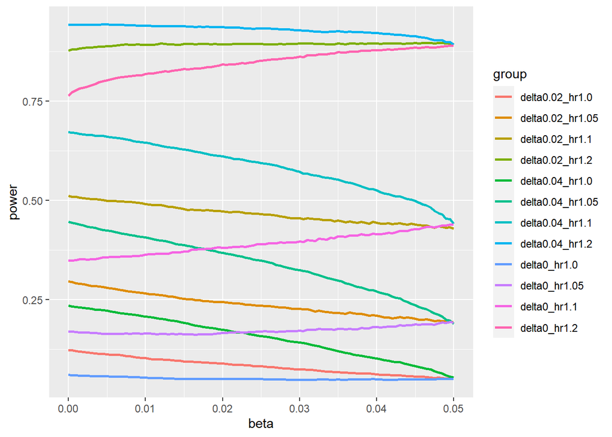

```r
ggplot(df, aes(beta, power, col=group)) +
  geom_line(size=1)
```

##### (2) q2 = mid (80%)

```r
power_delta0_hr1.0 = exp.seq.q2mid[1,1,] # Delta = 0, HR = 1
power_delta0_hr1.05 = exp.seq.q2mid[1,2,] # Delta = 0, HR = 1.05
power_delta0_hr1.1 = exp.seq.q2mid[1,3,] # Delta = 0, HR = 1.1
power_delta0_hr1.2 = exp.seq.q2mid[1,4,] # Delta = 0, HR = 1.2

power_delta0.02_hr1.0 = exp.seq.q2mid[2,1,] # Delta = 0.02, HR = 1
power_delta0.02_hr1.05 = exp.seq.q2mid[2,2,] # Delta = 0.02, HR = 1.05
power_delta0.02_hr1.1 = exp.seq.q2mid[2,3,] # Delta = 0.02, HR = 1.1
power_delta0.02_hr1.2 = exp.seq.q2mid[2,4,] # Delta = 0.02, HR = 1.2

power_delta0.04_hr1.0 = exp.seq.q2mid[3,1,] # Delta = 0.04, HR = 1
power_delta0.04_hr1.05 = exp.seq.q2mid[3,2,] # Delta = 0.04, HR = 1.05
power_delta0.04_hr1.1 = exp.seq.q2mid[3,3,] # Delta = 0.04, HR = 1.1
power_delta0.04_hr1.2 = exp.seq.q2mid[3,4,] # Delta = 0.04, HR = 1.2

df = data.frame(beta = rep(beta, 12),
group = rep(c("delta0_hr1.0","delta0_hr1.05","delta0_hr1.1","delta0_hr1.2",
              "delta0.02_hr1.0","delta0.02_hr1.05","delta0.02_hr1.1","delta0.02_hr1.2",
              "delta0.04_hr1.0","delta0.04_hr1.05","delta0.04_hr1.1","delta0.04_hr1.2"), each=length(beta)), power =
c(power_delta0_hr1.0, power_delta0_hr1.05, power_delta0_hr1.1, power_delta0_hr1.2,
  power_delta0.02_hr1.0,power_delta0.02_hr1.05,power_delta0.02_hr1.1,power_delta0.02_hr1.2,
  power_delta0.04_hr1.0,power_delta0.04_hr1.05,power_delta0.04_hr1.1,power_delta0.04_hr1.2))

df$beta[which(df$power[df$group=="delta0_hr1.0"] ==
                max(df$power[df$group=="delta0_hr1.0"]))]
```

```
## [1] 0
```

```r
df$beta[which(df$power[df$group=="delta0_hr1.05"] ==
                max(df$power[df$group=="delta0_hr1.05"]))]
```

```
## [1] 0.0490 0.0495 0.0500
```

```r
df$beta[which(df$power[df$group=="delta0_hr1.1"] ==
                max(df$power[df$group=="delta0_hr1.1"]))]
```

```
## [1] 0.049
```

```r
df$beta[which(df$power[df$group=="delta0_hr1.2"] ==
                max(df$power[df$group=="delta0_hr1.2"]))]
```

```
## [1] 0.0490 0.0495
```

```r
df$beta[which(df$power[df$group=="delta0.02_hr1.0"] ==
                max(df$power[df$group=="delta0.02_hr1.0"]))]
```

```
## [1] 0
```

```r
df$beta[which(df$power[df$group=="delta0.02_hr1.05"] ==
                max(df$power[df$group=="delta0.02_hr1.05"]))]
```

```
## [1] 0
```

```r
df$beta[which(df$power[df$group=="delta0.02_hr1.1"] ==
                max(df$power[df$group=="delta0.02_hr1.1"]))]
```

```
## [1] 0
```

```r
df$beta[which(df$power[df$group=="delta0.02_hr1.2"] ==
                max(df$power[df$group=="delta0.02_hr1.2"]))]
```

```
## [1] 0.02
```

```r
df$beta[which(df$power[df$group=="delta0.04_hr1.0"] ==
                max(df$power[df$group=="delta0.04_hr1.0"]))]
```

```
## [1] 0
```

```r
df$beta[which(df$power[df$group=="delta0.04_hr1.05"] ==
                max(df$power[df$group=="delta0.04_hr1.05"]))]
```

```
## [1] 0
```

```r
df$beta[which(df$power[df$group=="delta0.04_hr1.1"] ==
                max(df$power[df$group=="delta0.04_hr1.1"]))]
```

```
## [1] 0
```

```r
df$beta[which(df$power[df$group=="delta0.04_hr1.2"] ==
                max(df$power[df$group=="delta0.04_hr1.2"]))]
```

```
## [1] 0
```

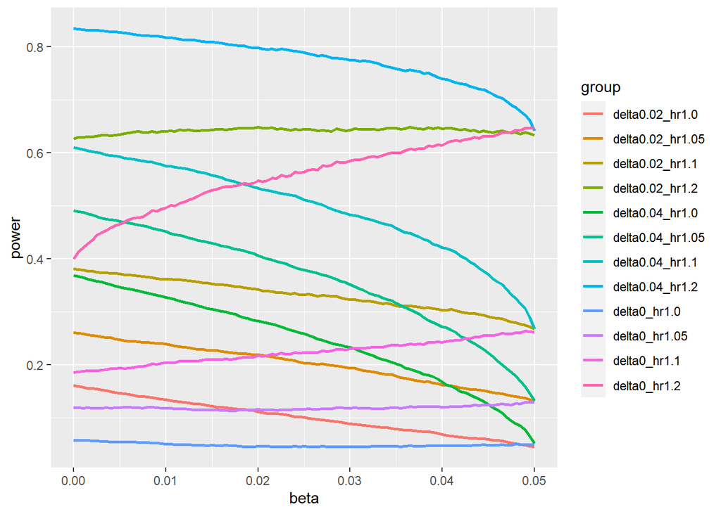

```r
ggplot(df, aes(beta, power, col=group)) +
  geom_line(size=1)
```

##### (3) q2 = high (90%)

```r
power_delta0_hr1.0 = exp.seq.q2high[1,1,] # Delta = 0, HR = 1
power_delta0_hr1.05 = exp.seq.q2high[1,2,] # Delta = 0, HR = 1.05
power_delta0_hr1.1 = exp.seq.q2high[1,3,] # Delta = 0, HR = 1.1
power_delta0_hr1.2 = exp.seq.q2high[1,4,] # Delta = 0, HR = 1.2

power_delta0.02_hr1.0 = exp.seq.q2high[2,1,] # Delta = 0.02, HR = 1
power_delta0.02_hr1.05 = exp.seq.q2high[2,2,] # Delta = 0.02, HR = 1.05
power_delta0.02_hr1.1 = exp.seq.q2high[2,3,] # Delta = 0.02, HR = 1.1
power_delta0.02_hr1.2 = exp.seq.q2high[2,4,] # Delta = 0.02, HR = 1.2

power_delta0.04_hr1.0 = exp.seq.q2high[3,1,] # Delta = 0.04, HR = 1
power_delta0.04_hr1.05 = exp.seq.q2high[3,2,] # Delta = 0.04, HR = 1.05
power_delta0.04_hr1.1 = exp.seq.q2high[3,3,] # Delta = 0.04, HR = 1.1
power_delta0.04_hr1.2 = exp.seq.q2high[3,4,] # Delta = 0.04, HR = 1.2

df = data.frame(beta = rep(beta, 12),
group = rep(c("delta0_hr1.0","delta0_hr1.05","delta0_hr1.1","delta0_hr1.2",
              "delta0.02_hr1.0","delta0.02_hr1.05","delta0.02_hr1.1","delta0.02_hr1.2",
              "delta0.04_hr1.0","delta0.04_hr1.05","delta0.04_hr1.1","delta0.04_hr1.2"), each=length(beta)), power =
c(power_delta0_hr1.0, power_delta0_hr1.05, power_delta0_hr1.1, power_delta0_hr1.2,
  power_delta0.02_hr1.0,power_delta0.02_hr1.05,power_delta0.02_hr1.1,power_delta0.02_hr1.2,
  power_delta0.04_hr1.0,power_delta0.04_hr1.05,power_delta0.04_hr1.1,power_delta0.04_hr1.2))

df$beta[which(df$power[df$group=="delta0_hr1.0"] ==
                max(df$power[df$group=="delta0_hr1.0"]))]
```

```
## [1] 0
```

```r
df$beta[which(df$power[df$group=="delta0_hr1.05"] ==
                max(df$power[df$group=="delta0_hr1.05"]))]
```

```
## [1] 0.0495
```

```r
df$beta[which(df$power[df$group=="delta0_hr1.1"] ==
                max(df$power[df$group=="delta0_hr1.1"]))]
```

```
## [1] 0.0495 0.0500
```

```r
df$beta[which(df$power[df$group=="delta0_hr1.2"] ==
                max(df$power[df$group=="delta0_hr1.2"]))]
```

```
## [1] 0.0495
```

```r
df$beta[which(df$power[df$group=="delta0.02_hr1.0"] ==
                max(df$power[df$group=="delta0.02_hr1.0"]))]
```

```
## [1] 0
```

```r
df$beta[which(df$power[df$group=="delta0.02_hr1.05"] ==
                max(df$power[df$group=="delta0.02_hr1.05"]))]
```

```
## [1] 0
```

```r
df$beta[which(df$power[df$group=="delta0.02_hr1.1"] ==
                max(df$power[df$group=="delta0.02_hr1.1"]))]
```

```
## [1] 0
```

```r
df$beta[which(df$power[df$group=="delta0.02_hr1.2"] ==
                max(df$power[df$group=="delta0.02_hr1.2"]))]
```

```
## [1] 0
```

```r
df$beta[which(df$power[df$group=="delta0.04_hr1.0"] ==
                max(df$power[df$group=="delta0.04_hr1.0"]))]
```

```
## [1] 0
```

```r
df$beta[which(df$power[df$group=="delta0.04_hr1.05"] ==
                max(df$power[df$group=="delta0.04_hr1.05"]))]
```

```
## [1] 0
```

```r
df$beta[which(df$power[df$group=="delta0.04_hr1.1"] ==
                max(df$power[df$group=="delta0.04_hr1.1"]))]
```

```
## [1] 0
```

```r
df$beta[which(df$power[df$group=="delta0.04_hr1.2"] ==
                max(df$power[df$group=="delta0.04_hr1.2"]))]
```

```
## [1] 0
```

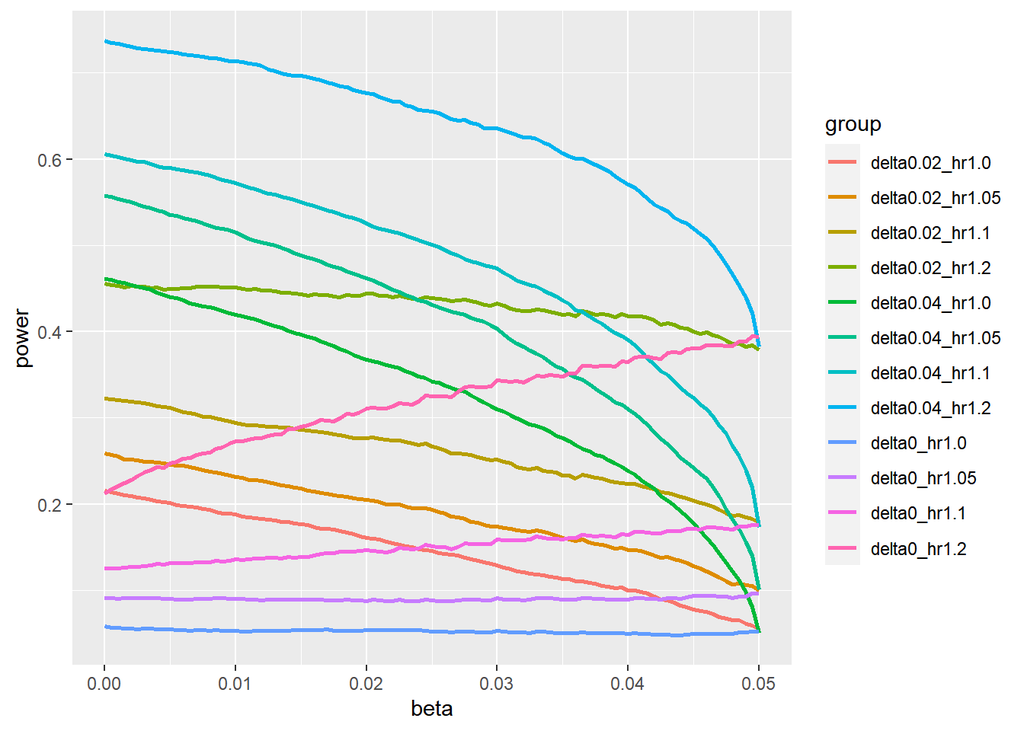

```r
ggplot(df, aes(beta, power, col=group)) +
  geom_line(size=1)
```